# Utiliser R Markdown pour créer des documents dynamiques

29 avril 2015

## Écrire un article scientifique

### ou le chronophage formatage

## Notre pain quasi quotidien

- Organisation de la science moderne
- Données \(\rightarrow\) analyses \(\rightarrow\) figures \(\rightarrow\) manuscrit
- Scientifique \(\rightarrow\) manuscrit \(\rightarrow\) éditeurs \(\rightarrow\) reviewers \(\rightarrow\) journal ( si non, \(\rightarrow\) manuscrit)
- Système de préparation de document : "Word vs Latex"

## Word vs Latex

- une tentative de comparaison objective…

[figure not shown]

## Word vs Latex

- "We believe that the use of LaTeX under these circumstances is highly problematic and that researchers should reflect on the criteria that drive their preferences to use LaTeX over Microsoft Word for text that does not require significant mathematical representations."
- "A striking result of our study is that LaTeX users are highly satisfied with their system despite reduced usability and productivity."

## Word vs Latex

- "LaTeX is meant to separate contents from layout, and the people who use it regularly tend value that separation."
- "Set up 50 numbered equations, refer to them throughout the text, then change the equation order."

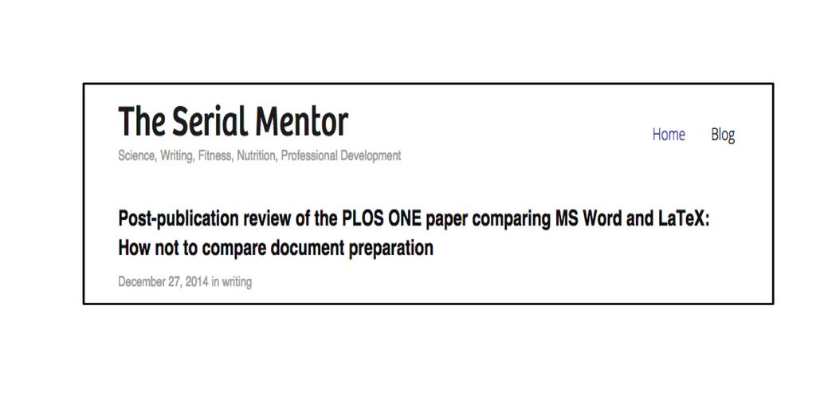

## Mais finalement …

- C'est toujours au scientifique d'être plus performant dans l'écriture.
- Est-ce là le fondement d'une science de qualité ?
- Pourquoi ne pas envisager un système globalement plus performant…?

## Ne pas formater un manuscrit

- "Editors should be satisfied with a readable, generic submission. Authors would format the article after acceptance."

[figure not shown]

## Markdown et Pandoc, un nouveau paradigme ?

- "The most exciting current developments, in my mind, are happening with Markdown."
- Pour faire simple :
  - Markdown : un latex light
  - [Pandoc](http://pandoc.org) : un convertisseur de document très puissant

## Markdown et R Markdown

## R Markdown nn bref

- R Markdown = Pandoc Markdown + knitr + YAML + des templates solides
- Tout ça pour produire, grâce à Pandoc :
  - 4 sortes de documents : html, pdf, md, docx
  - 3 types de présentation : ioslides, slidy et beamer
- Documents et présentation avec du code et des figures R
- Données \(\rightarrow\) analyses \(\rightarrow\) figures \(\rightarrow\) manuscrit

## Markdown, Ok je vois un peu

- [Markdown](http://daringfireball.net/projects/markdown/), première version 2004
- Depuis, plusieurs variantes : kramdown, Multimarkdown, Pandoc markdown, …

## et YAML ?

- "[…] format de représentation de données par sérialisation Unicode" [wikipedia](http://fr.wikipedia.org/wiki/YAML)
- Retenons : format pour préciser les commandes Pandoc et le contenu des templates de manière intuitive.

## et Knitr ?

- Package de R pour inclure du code R dans un document devenu dynamique
- Le [site associé](http://yihui.name/knitr/) est très riche en information
- Les templates solides, on va y croire les yeux fermés…

## Résumons un peu

R Markdown = Pandoc Markdown + knitr + YAML + des templates solides

## Le fichier .rmd

### un fichier pour les générer tous

## Les différents langages

- Le YAML entre : - - -
- Le code R entre : ` ` `
- Le texte écrit utilise la syntaxe [Pandoc markdown](http://rmarkdown.rstudio.com/authoring_pandoc_markdown.html)

## Ce dont on a besoin

- Package [rmarkdown](http://cran.r-project.org/web/packages/rmarkdown/index.html)
- Packages dont dépend rmarkdown seront installées avec.
- Si vous utilisez Rstudio, tout doit être prêt sauf…
- [Latex](http://www.tug.org/texlive/) pour obtenir les pdf

## La fonction *render*

Pour obtenir nos fichiers, plusieurs étapes :

1. Repérer les morceaux de codes R
2. Les exécuter, enregistrer les figures (un dossier est créé)
3. Un fichier global en Markdown est créé
4. Pour chaque format souhaité, une commande Pandoc est créée -YAML-
5. La commande est ensuite exécutée

## La fonction *render*

- render("path/myfile.rmd")
- render("path/myfile.rmd","all")
- ou quelques clics sur RStudio

## Pandoc Markdown et morceaux de code R

- La présente présentation et le document associé
- Le [*Cheat Sheet*](http://www.rstudio.com/wp-content/uploads/2015/02/rmarkdown-cheatsheet.pdf) sur RStudio
- [Présentation de Mansun Kuo sur Rpubs](http://rpubs.com/mansun_kuo/24330)

## D'autres langages ?

Vous pouvez écrire en Latex ou HTML mais …

Attention !

\(\Rightarrow\) Il existe un trade-off "généralité vs spécificité"

## Les équations c'est facile…

\[\frac{vache}{oiseau} = \frac{2\pi}{l}\]

## Les équations c'est facile…

\[\frac{vache}{oiseau} = \frac{2\pi}{l}\]

\[\frac{vache}{oiseau} = \frac{\beta 4 \pi}{\beta 2 l}\]

## Un exemple de code pour générer…

```r
kcircle <- function(rad=1,centre=c(0,0),from=0,to=2*pi,dt=0.001,...){
    pt <- seq(from, to, dt)
    polygon(centre[1]+rad*cos(pt),centre[2]+rad*sin(pt),...)
}
plot(c(-1.5,1.5), c(-1.5,1.5), asp=1, type="n", ann=FALSE,
    axes=FALSE, xaxs="i", yaxs="i")
kcircle(col="#AA000088")
for (i in 1:6) kcircle(1,c(cos(i*pi/3),sin(i*pi/3)), col="#0000AA88")
```

## Ma rosace

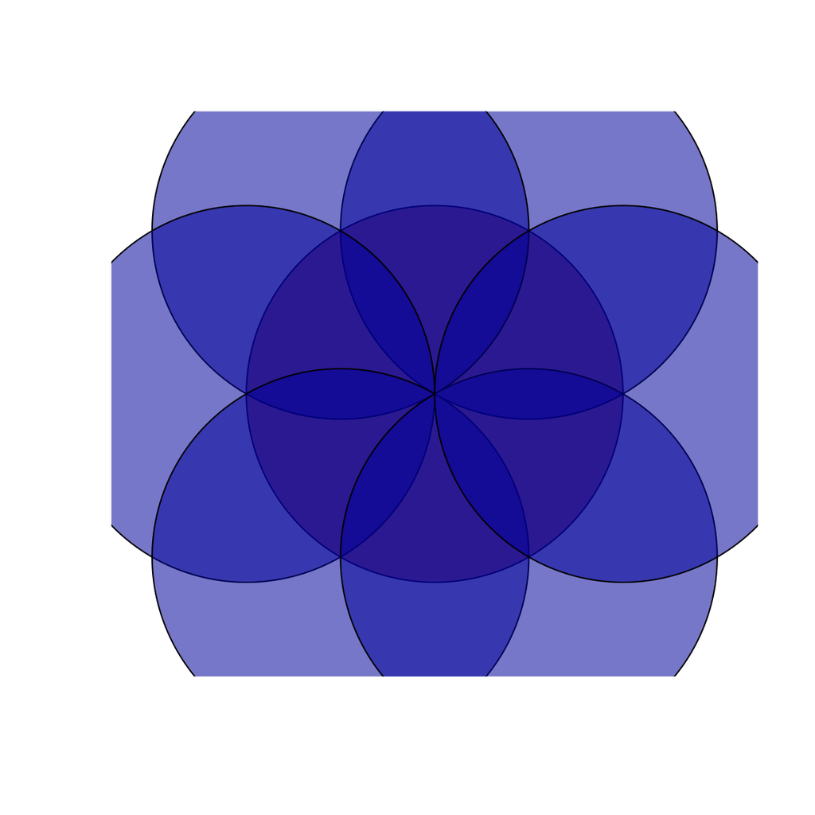